# Лабораторная работа №12

Настройка сети в Linux

Ришард Когенгар

Российский университет дружбы народов, Москва, Россия

18 января 2026

# Цель работы

## Основная цель

Получить практические навыки настройки и диагностики сетевых параметров  
в операционной системе Linux.

# Ход выполнения работы

## Сетевые интерфейсы и статистика

- Использование утилиты `ip`
- Обнаружены интерфейсы:
  - lo — loopback
  - enp0s3 — основной сетевой адаптер
- Анализ состояния, MTU, MAC-адреса, RX/TX

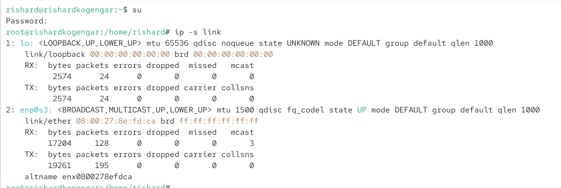

Статистика сетевых интерфейсов

## Таблица маршрутизации

- Просмотр текущих маршрутов
- Маршрут по умолчанию через шлюз
- Локальная сеть подключена напрямую

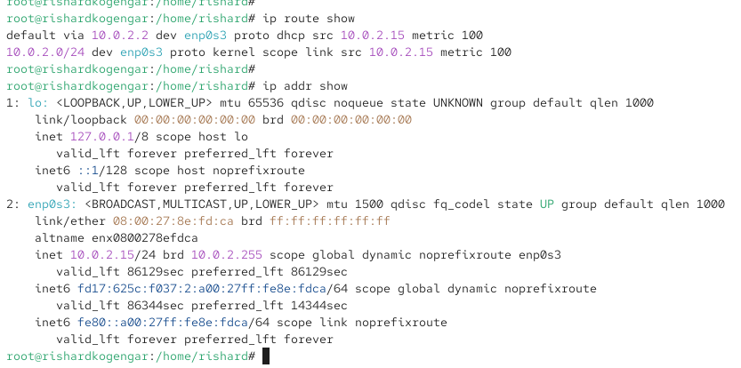

Таблица маршрутизации

## Проверка доступа в Интернет

- Отправка ICMP-пакетов на 8.8.8.8
- Потери пакетов отсутствуют
- Подключение работает корректно

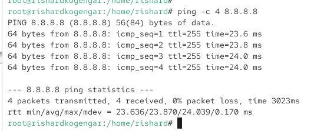

Проверка ping

## Добавление дополнительного IP-адреса

- Добавлен второй IPv4-адрес
- Интерфейс обслуживает несколько подсетей

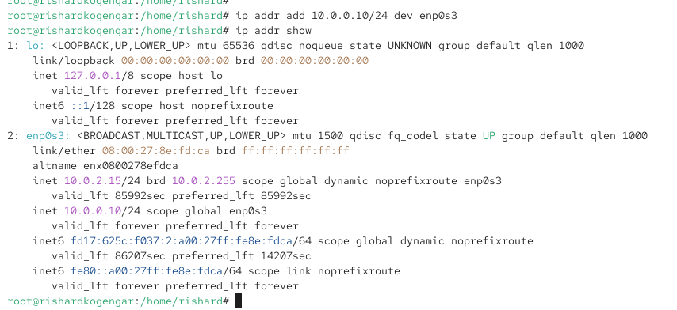

Добавленный IP-адрес

## Сравнение ip и ifconfig

- ifconfig — базовая информация
- ip — расширенные и актуальные данные
- Рекомендуется использование ip

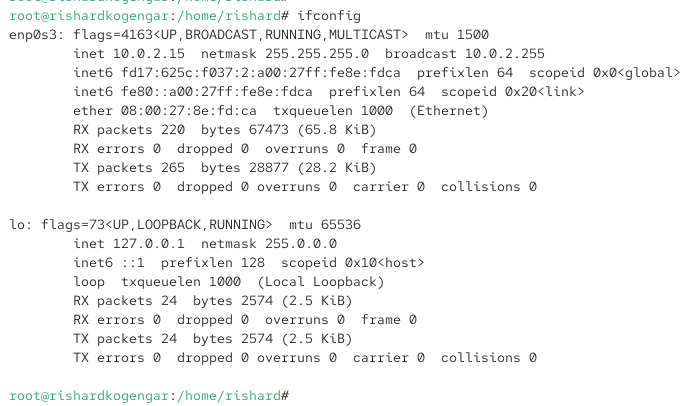

Вывод ifconfig

## Прослушиваемые порты

- Просмотр TCP и UDP портов
- Обнаружены службы:
  - SSH
  - HTTP
  - FTP
  - IPP
  - mDNS

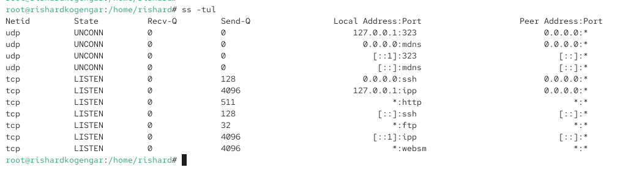

Список портов

## DHCP и статическое соединение

- Создан профиль dhcp
- Создан профиль static
- Статическое подключение без автозапуска

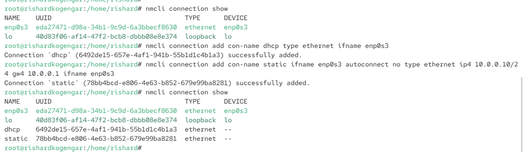

Создание подключений

## Переключение профилей

- Активация static
- Проверка IP-адреса
- Возврат к dhcp

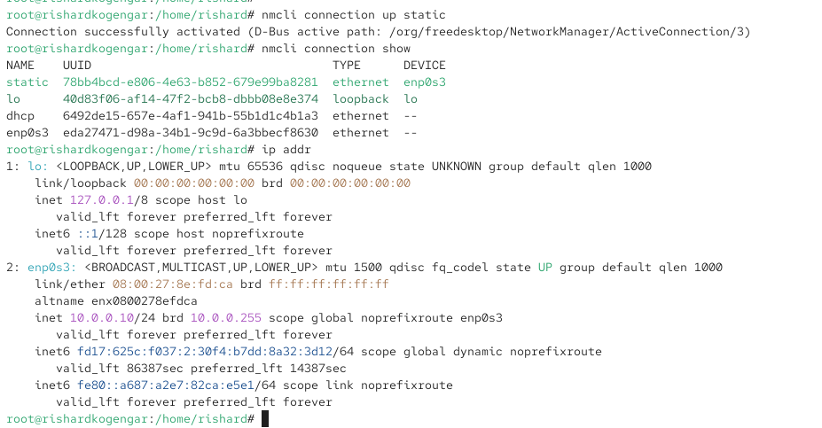

Переключение подключений

## Настройка DNS и IP-адресов

- Добавлены DNS-серверы
- Назначены два IPv4-адреса
- Использование параметров ipv4 и +

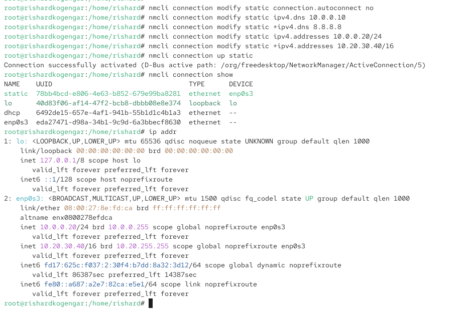

Изменение параметров static

## Проверка активного соединения

- Static-профиль активен
- Интерфейс enp0s3 имеет несколько адресов

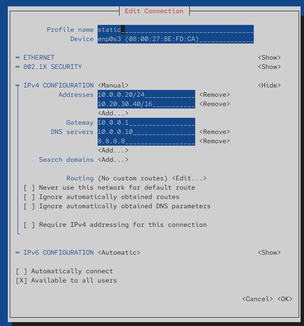

Проверка IP-адресов

## Просмотр настроек в nmtui

- Текстовый интерфейс NetworkManager
- Проверка адресов, шлюза и DNS

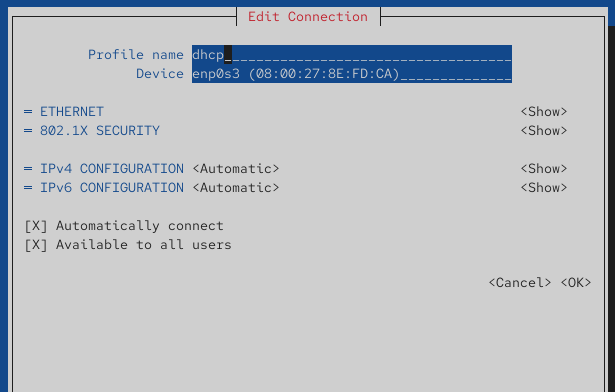

Настройки в nmtui

## Графический интерфейс сети

- Просмотр параметров static и dhcp
- Сравнение ручной и автоматической конфигурации

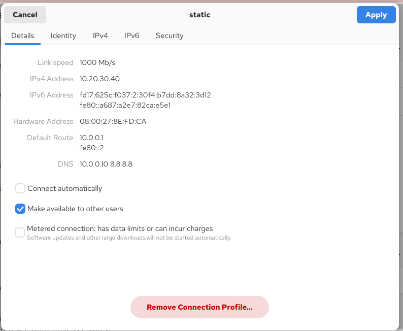

Static GUI

## Графический интерфейс сети

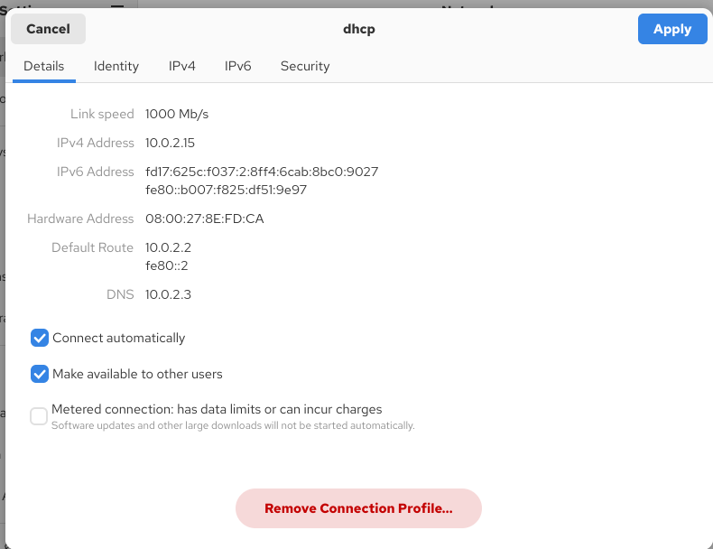

DHCP GUI

# Итоги работы

## Вывод

- Изучены инструменты диагностики сети Linux
- Освоена настройка сети через NetworkManager
- Отработано управление DHCP и статическими профилями
- Подтверждена корректная работа сетевой подсистемы